# Pitcher Precision

Sasank Vishnubhatla

4/17/2019

Last Update: 2019-04-22 11:19:17

# Libraries

Let’s load some libraries in first.

```r
library(baseballr)
library(pitchRx)
library(tidyverse)
```

Let’s also clean out environment.

```r
rm(list = ls())
```

With these libraries, we can get out data as well as visaulize it. Let’s take a look at some players to see what we can look at.

# Data Loading

Here are the list of players I will be looking at.

- Noah Syndergaard - Player ID: 592789
- Patrick Corbin - Player ID: 571578
- Felipe Vazquez - Player ID: 553878
- Marcus Stroman - Player ID: 573186
- Justin Verlander - Player ID: 434378
- Blake Treinen - Player ID: 595014

Let’s now scrape the data for each player.

```r
scrape.data = function(start, id) {
    data = scrape_statcast_savant(start_date = start,
                                  end_date = "2019-04-22",
                                  playerid = id,
                                  player_type = 'pitcher')
    data
}

start = "2019-01-01"

syndergaard.data = scrape.data(start, 592789)
corbin.data = scrape.data(start, 571578)
vazquez.data = scrape.data(start, 553878)
stroman.data = scrape.data(start, 573186)
verlander.data = scrape.data(start, 434378)
treinen.data = scrape.data(start, 595014)
```

Now with our data, let’s get the information we want out of it.

```r
filter.data = function(data) {
    filtered = data.frame(name = data %>% pull(player_name),
                          pitch = data %>% pull(pitch_type),
                          outcome = data %>% pull(type),
                          date = data %>% pull(game_date),
                          event = data %>% pull(events),
                          descrip = data %>% pull(description),
                          xcoord = data %>% pull(plate_x),
                          ycoord = data %>% pull(plate_z),
                          xmove = data %>% pull(pfx_x),
                          ymove = data %>% pull(pfx_z),
                          velo = data %>% pull(effective_speed),
                          spin = data %>% pull(release_spin_rate),
                          exvelo = data %>% pull(launch_speed),
                          exang = data %>% pull(launch_angle))
    filtered
}

syndergaard = filter.data(syndergaard.data)
corbin = filter.data(corbin.data)
stroman = filter.data(stroman.data)
treinen = filter.data(treinen.data)
vazquez = filter.data(vazquez.data)
verlander = filter.data(verlander.data)
```

With this filtered data, we have selected the following columns:

- Name
- Pitch type
- Pitch outcome (Strike, Ball, In play)
- Game Date
- Event
- Description of event
- X coordinate (horizontal location) of pitch
- Y coordinate (vertical location) of pitch
- Horizontal movement (X coordinate movement) of pitch
- Vertical movement (Y coordinate movement) of pitch
- Velocity of pitch
- Spin rate of pitch
- Exit velocity of pitch
- Launch angle of pitch

# Visualization

Let’s start visualizing some of this data.

## Pitch Location

First, let’s look at pitch location.

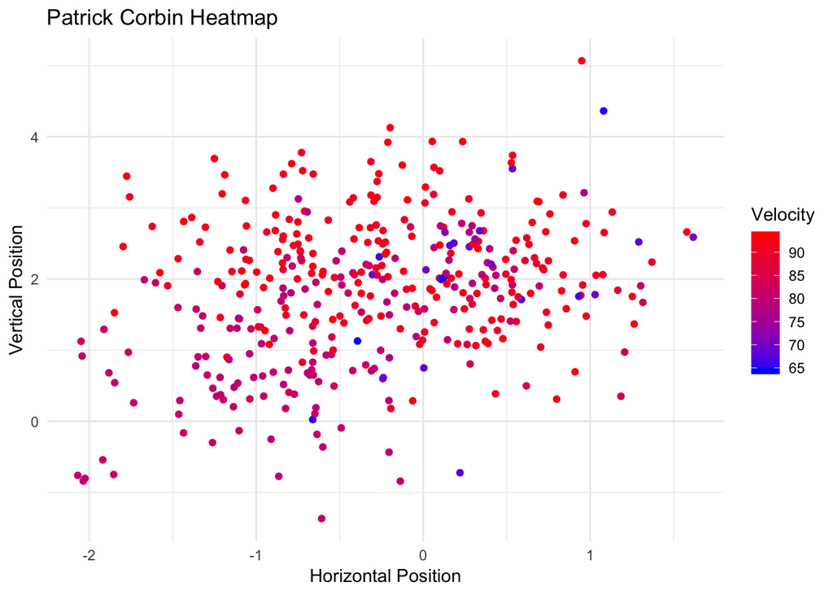

```r
graph.pitch.heatmap = function(player.data) {
    graph = ggplot(player.data) +
        geom_jitter(aes(x = player.data$xcoord,
                        y = player.data$ycoord,
                        color = player.data$velo))+
        xlab("Horizontal Position") +
        ylab("Vertical Position") +
        ggtitle(paste(player.data$name[1], "Heatmap", sep = " ")) +
        labs(color = "Velocity") +
        scale_color_gradient(low = "blue", high = "red") +
        theme_minimal()
    graph
}

corbin.heatmap = graph.pitch.heatmap(corbin)
corbin.heatmap
```

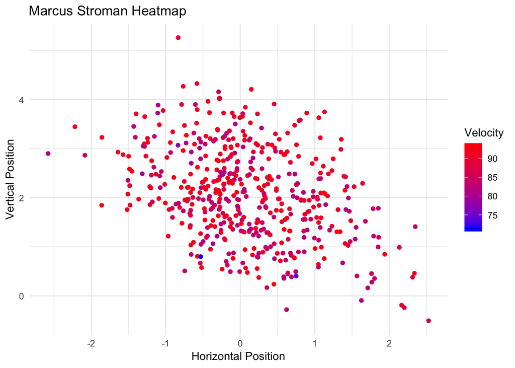

```r
stroman.heatmap = graph.pitch.heatmap(stroman)
stroman.heatmap
```

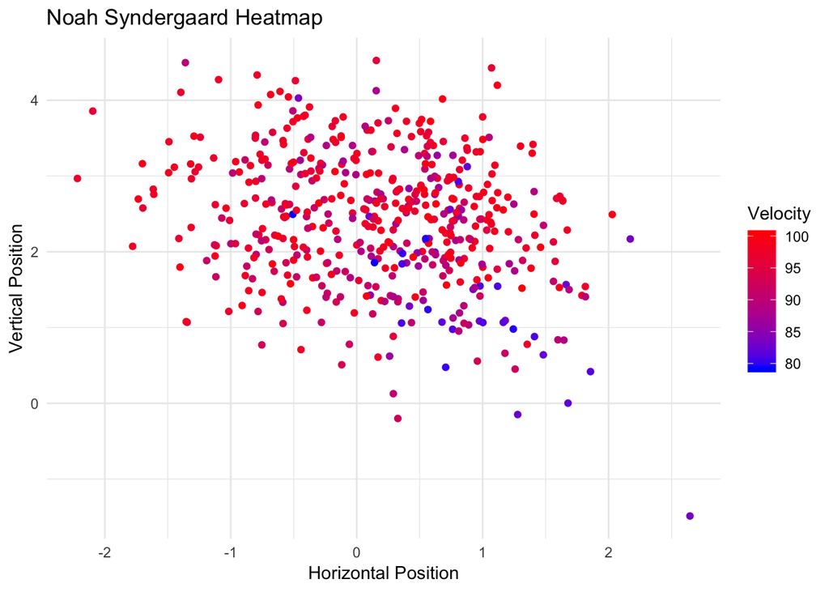

```r
syndergaard.heatmap = graph.pitch.heatmap(syndergaard)
syndergaard.heatmap
```

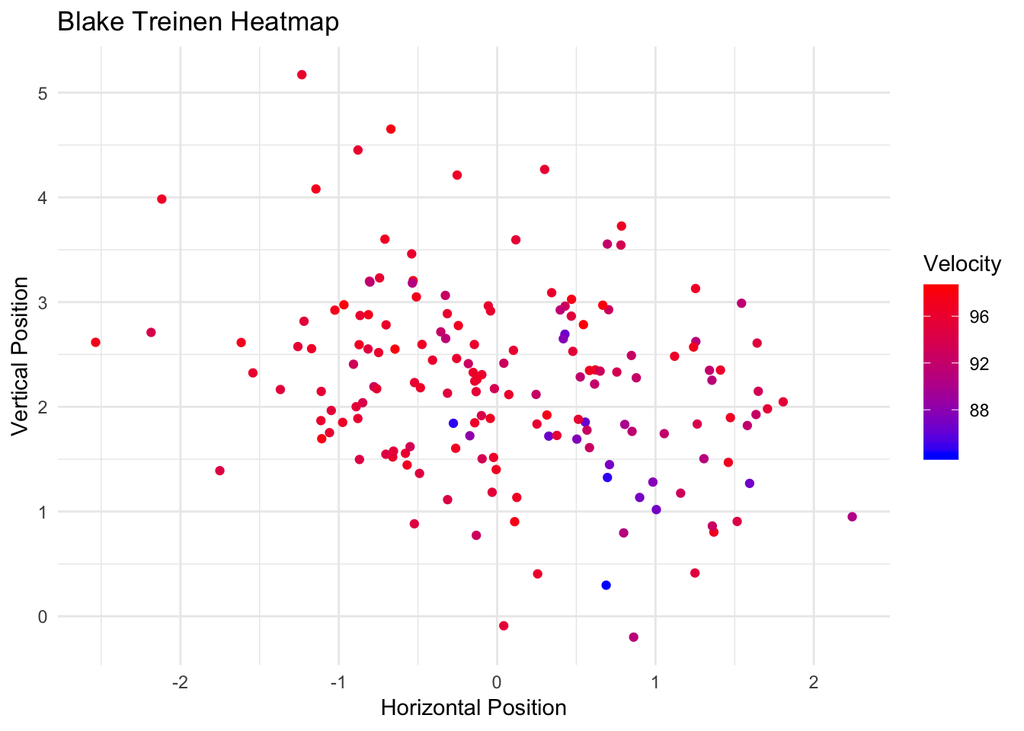

```r
treinen.heatmap = graph.pitch.heatmap(treinen)
treinen.heatmap
```

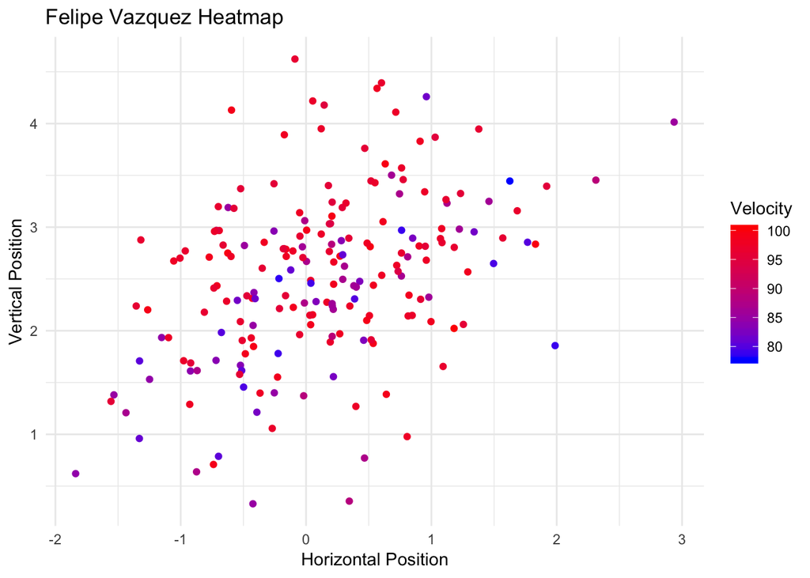

```r
vazquez.heatmap = graph.pitch.heatmap(vazquez)
vazquez.heatmap
```

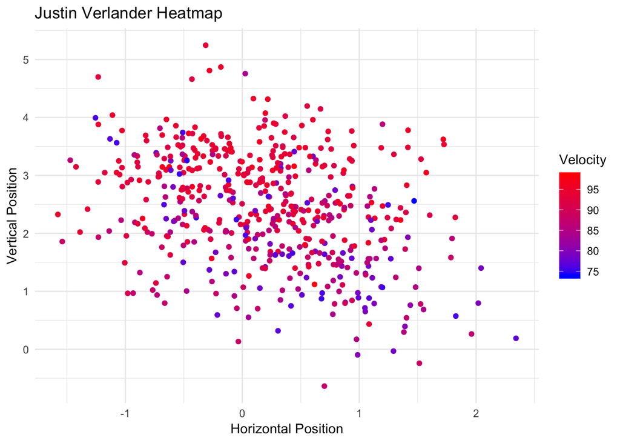

```r
verlander.heatmap = graph.pitch.heatmap(verlander)
verlander.heatmap
```